# TRANSFORMADA DE FOURIER EN TIEMPO DISCRETO (DTFT)

## SISTEMAS Y SEÑALES

### Ingenieria de Telecomunicaciones

### Universidad Pontificia Bolivariana

### Por: Jose R. Zapata - https://joserzapata.github.io/

**joser.zapata@upb.edu.co**

```python
# Script para ver y ocultar el codigo del jupyter
from IPython.display import HTML

HTML('''<script>
  function code_toggle() {
    if (code_shown){
      $('div.input').hide('500');
      $('#toggleButton').val('Ver el Codigo de Python')
    } else {
      $('div.input').show('500');
      $('#toggleButton').val('Ocultar el Codigo')
    }
    code_shown = !code_shown
  }

  $( document ).ready(function(){
    code_shown=false;
    $('div.input').hide()
  });
</script>
<form action="javascript:code_toggle()">
<input type="submit" id="toggleButton" value="Ver el Codigo de Python"></form>''')
```

# Transformada de Fourier en Tiempo Discreto (DTFT)

De forma análoga a la realizada para señales continuas, podemos deducir la expresión de la transformada de Fourier para señales discretas, obteniendo:

$$ \large \boxed{X(e^{j\Omega}) = \displaystyle \sum_{n=-\infty}^{+\infty} x[n]\cdot e^{-j\Omega n}} $$

Para calcular la anti-transformada, podemos aprovecharnos del hecho que $\large X(j \Omega) \cdot e^{j \Omega n}$ es periódica de periodo $2 \pi$ y reducir la integral infinita a cualquier periodo de esa extensión. Nos queda que:

$$ \large \boxed{x[n] = \frac{1}{2\pi} \displaystyle \int_{2\pi} X(e^{j\Omega})\cdot e^{j\Omega n} d\Omega} $$

La principal diferencia con la transformada de tiempo continuo es qeu el especro es periodica y el intervalo de integracion es continuo

- Baja frecuencia alrededor de $\Omega = 0 , \Omega = 2 \pi$
- Alta frecuencia alrededor de $\Omega = - \pi , \Omega = \pi$

# Convergencia

Para que sea convergente solo basta que sea absolutamente sumable o energia finita. $$ \large \sum_{n=- \infty}^{\infty} \left|x[n] \right| < \infty $$

En las señales discretas no se presenta el fenomeno de Gibbs.

# Ejercicio

$x[n] = a^n \mu[n]$ para $|a|<1$

# Tranformadas Discretas de Fourier de Señales Especiales

## DTFT Impulso de Dirac

La transformada $\mathcal{F} \{ \delta[k] \}$ de un impulso de diracces igual a

$$ \mathcal{F}\{ \delta[k] \} = \sum_{k = -\infty}^{\infty} \delta[k] \, e^{-j \Omega k} = 1 $$

La transformación del impulso de Dirac es igual a uno. Por lo tanto, todas las frecuencias normalizadas $\Omega$ están presentes con el mismo peso. Esta es una propiedad importante en la teoría de señales y sistemas discretos, ya que el impulso de Dirac se utiliza para caracterizar los sistemas lineales invariantes en el tiempo (LTI) por su respuesta de impulso $h[k] = \mathcal{H} \{ \delta[k] \}$.

## DTFT de un Pulso Rectangular

El DTFT $X(e^{j \Omega}) = \mathcal{F}\{\text{rect}_N[k] \}$ de la señal rectangular se deriva al introducir su definición en la definición de DTFT. Esto resulta en

$$ \mathcal {F} \{\text{rect}[k] \} = \sum_{k = - \infty} ^ {\infty} \text{rect}[k] \, e^ {-j \Omega k} = \sum_{k = 0}^{N-1} e^{-j\Omega k} = e^{-j \Omega \frac {N-1} {2}} \cdot \frac {\sin \left (\frac {N \Omega} {2} \right)} {\sin \left (\frac {\Omega} {2} \right)} $$

La última igualdad se ha derivado al señalar que la suma constituye una [serie geométrica finita](https://es.wikipedia.org/wiki/Serie_geom%C3%A9trica) con la proporción común $e^{-j \Omega}$. Tenga en cuenta que

$$ \frac {\sin \left (\frac {N \Omega} {2} \right)} {\sin \left (\frac {\Omega} {2} \right)} \bigg \rvert _ {\Omega = n \cdot 2 \pi} = N $$

Para $n \in \mathbb{Z}$ debido a la regla de L'Hôpital.

### Ejemplo

La DTFT $X(e^{j \Omega}) = \mathcal{F} \{ \text{rect}_N[k] \}$ de una señal rectangular se calcula para una longitud especifica de $N$ y evaluando las series finitas de la serie que se encuentra arriba usando `SymPy`, obtenemos:

```python
%matplotlib inline
import sympy as sym
sym.init_printing()

W = sym.symbols('Omega', real=True)
k = sym.symbols('k', integer=True)

N = 5
print(f'Para N = {N}')
X = sym.summation(sym.exp(-sym.I*W*k), (k, 0, N-1))
X
```

```
Para N = 5
```

$\displaystyle 1 + e^{- i \Omega} + e^{- 2 i \Omega} + e^{- 3 i \Omega} + e^{- 4 i \Omega}$

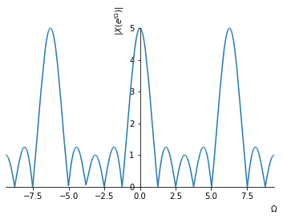

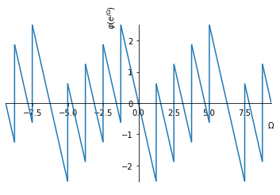

```python
sym.plot(sym.Abs(X), (W, -3*sym.pi, 3*sym.pi), xlabel=r'$\Omega$', ylabel=r'$| X(e^{j \Omega}) |$')
sym.plot(sym.arg(X), (W, -3*sym.pi, 3*sym.pi), xlabel=r'$\Omega$', ylabel=r'$\varphi(e^{j \Omega})$');
```

**Ejercicio**

¿Que ocurre con el diagrama de Magnitud y de Fase si aumenta o disminuye la longitud N de la señal rectangular?

# Transformada de Fourier Discreta para Señales Periodicas

El desarrollo es el mismo realizado para la transformada de tiempo continuo, que es considerando $x[n] = e^{j \Omega_0 n}$ su transformada de Fourier es un impulso en $\Omega = \Omega_0 , \; \Omega_0 \pm 2\pi, \;\Omega_0 \pm 4\pi, ...$ y la transformada de Fourier de $x[n]$ es: $$ \large X(e^{j\Omega}) = \sum_{l=-\infty}^{+\infty} 2\pi \; \delta(\Omega - \Omega_0 - 2\pi l) \rightarrow \\ \large X(e^{j\Omega}) = 2\pi \sum_{k=-\infty}^{+\infty} a_k \; \delta \left( \Omega - \frac{2\pi k}{N} \right) $$

## Ejercicios

- Calcular la DTFT de $x[n] = \cos(\omega_0 n )$ si $\omega_0 = \frac{2 \pi}{5}$

# Propiedades de la Tranformada Discreta de Fourier

Para todas estas propiedades, supondremos que $\mathcal{F}[x[n]] = X(j\Omega)$ y por lo tanto $x[n] = \mathcal{F}^{-1}[X(j\Omega)]$

## Periodicidad

La transformada de Fourier en tiempo discreto es SIEMPRE periódica en $\Omega$ con periodo $2 \pi$: $$ \large X(e^{j(\Omega + 2\pi)}) = X(e^{j\Omega}) $$

## Linealidad

$$ \large \mathcal{F}[A\cdot x[n]+B\cdot y[n]] = A\cdot X(e^{j\Omega})+B\cdot Y(e^{j\Omega}) $$

## Desplazamiento en el Tiempo y Frecuencia

$$ \large \mathcal{F}[x[n-n_0]] = e^{-j\Omega n_0}\cdot X(e^{j\Omega}) $$$$ \large \mathcal{F}[x[n]\cdot e^{j\Omega_0 n}] = X(e^{j(\Omega - \Omega_0 )}) $$

## Conjugacion y Simetria Conjugada

$$ \large \mathcal{F}[x*[n]] = X*(e^{-j\Omega}) $$

Si x[n] es Real: $X(e^{j\Omega}) = X*(e^{-j\Omega})$

## Diferenciacion y Acumulacion

$$ \large \mathcal{F}[x[n]-x[n-1]] = (1-e^{j\Omega})\cdot X(e^{j\Omega}) $$$$ \large \mathcal{F}\left[\sum_{m=-\infty}^n x[m]\right] = \frac{1}{1-e^{-j\Omega}}\cdot X(e^{j\Omega}) + \pi X(e^{j 0})\sum_{k=-\infty}^{+\infty}\delta(\Omega-2\pi k) $$

**Ejercicio**

¿Cual es la DTFT de $\mu[n]$?

## Inversion en el Tiempo

$$ \large \mathcal{F}[x[-n]] = X(e^{-j\Omega}) $$

## Escalamiento de Tiempo

Si $\large x_{(k)}[n], \;con\;k\in\mathbb{N} = \left\{\begin{array}{ll}x[n/k]&&si\;n\;es\;multiplo\;de\;k\\0&&si\;n\;no\;es\;multiplo\;de\;k\end{array}\right.$:

$$ \large \mathcal{F}[x_{(k)}[n]] = X(e^{j k \Omega}) $$

## Diferenciacion en Frecuencia

$$ \large \mathcal{F}[n\cdot x[n]] = j\frac{dX(e^{j\Omega})}{d\Omega} $$

## Relacion de Parseval

$$ \large \sum_{n=-\infty}^{+\infty} |x[n]|^2 = \frac{1}{2\pi}\int_{2\pi} |X(e^{j\Omega})|^2 d\Omega $$

## Convolucion

$$ \large y[n] = h[n]*x[n] ~\Rightarrow~ Y(e^{j\Omega}) = H(e^{j\Omega})\cdot X(e^{j\Omega}) $$

Se puede calcular la convolución de dos señales multiplicando sus transformadas de Fourier y luego calculando su antitransformada para obtener la respuesta en el dominio del tiempo

## Multiplicacion o Modulacion

$$ \large r[n] = s[n]·p[n] ~\Rightarrow~ R(e^{j\Omega}) = \displaystyle \frac{1}{2\pi}\int_{2\pi} S(e^{j\theta})·P(e^{j(\Omega-\theta)}) ·d\theta $$

# Sistemas Caracterizados por Ecuaciones en Diferencias con Coeficientes Constantes

$$ \large \sum_{k=0}^{N} a_k \; y[n-k] = \sum_{m=0}^{M} b_m \; x[n-m] $$

Si se le aplica la DTFT obtenemos: $$ \large \sum_{k=0}^{N} a_k \; e^{-j k \Omega} Y(e^{j \Omega}) = \sum_{m=0}^{M} b_m \; e^{-j m \Omega} X(e^{j \Omega}) \\ \large H(e^{j \Omega}) = \frac{Y(e^{j \Omega})}{X(e^{j \Omega})} = \frac{\sum_{m=0}^{M} b_m \; e^{-j m \Omega}}{\sum_{k=0}^{N} a_k \; e^{-j k \Omega}} $$

## Ejemplo

Calcular la $H(e^{j \Omega})$ y $h[n]$de:

$y[n] - ay[n-1] = x[n]$ con $|a|<1$

$$ H(e^{j \Omega}) = \frac{1}{1-a \cdot e^{-j \Omega}} \\ h[n]= a^n \mu[n] $$

## Ejercicio

Calcular la $H(e^{j \Omega})$ y $h[n]$de:

$y[n] - \frac{3}{4}y[n-1] + \frac{1}{8}y[n-2] = 2 x[n]$

# Referencia

- https://nbviewer.jupyter.org/github/spatialaudio/signals-and-systems-lecture/blob/master/discrete_time_fourier_transform/definition.ipynb
- https://nbviewer.jupyter.org/github/spatialaudio/signals-and-systems-lecture/blob/master/discrete_time_fourier_transform/theorems.ipynb
- http://19e37.com/wiki/index.php?title=Propiedades_de_la_transformada_de_Fourier_en_tiempo_discreto

**Phd. Jose R. Zapata**

- https://joserzapata.github.io/
- https://twitter.com/joserzapata
- joser.zapata@upb.edu.co